# Landscape Study - General Overview

Thomas Klebel

Last changed 2020-07-05

# Summary

The general impression is, that the journals most of the time do not have a specific policy regarding the aspect under question, or it was unclear for our reviewers if there was a policy or not or how to interpret it.

# Missing data

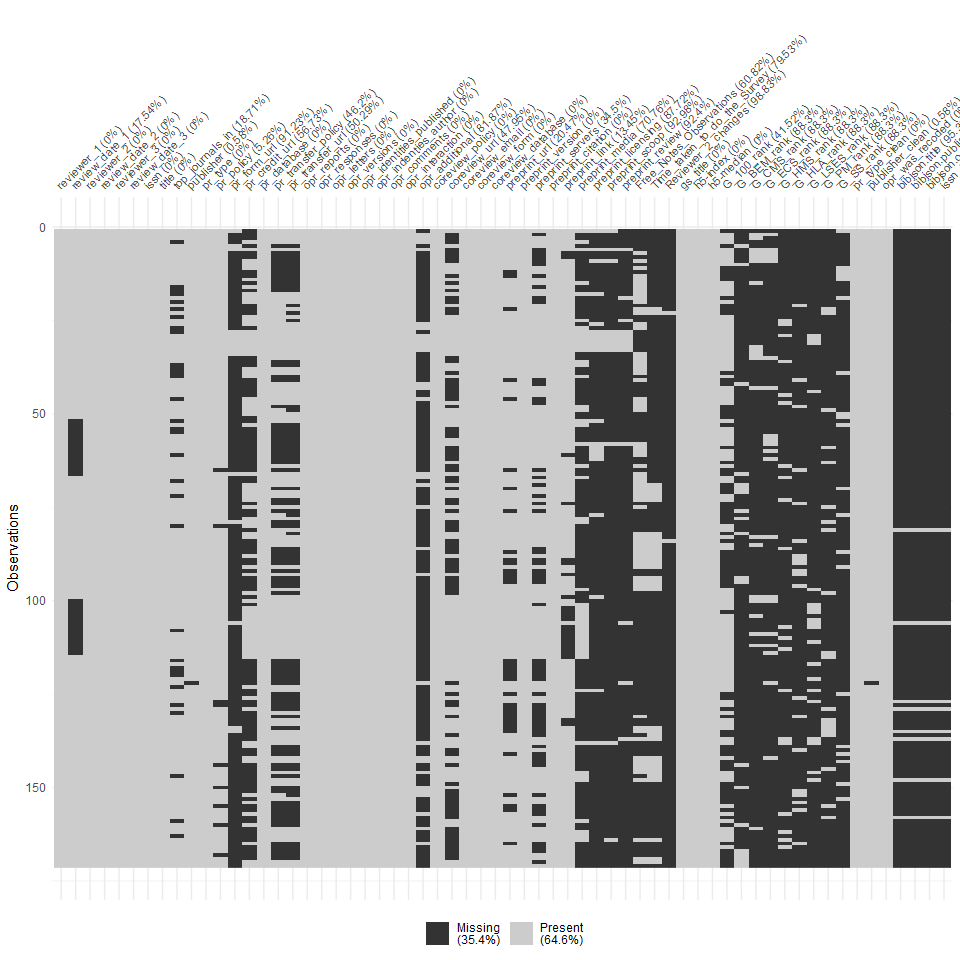

There is quite some missing data, which shouldn’t be like this. For example the field U30 in excel (table RAW), which has the opr-responses for the journal “Advanced Materials” is missing. It should probably be “Not specified”.

The following are all variables, where implicit missings should be checked and converted to explicit ones (as for opr_responses), or fixed (as for publishers).

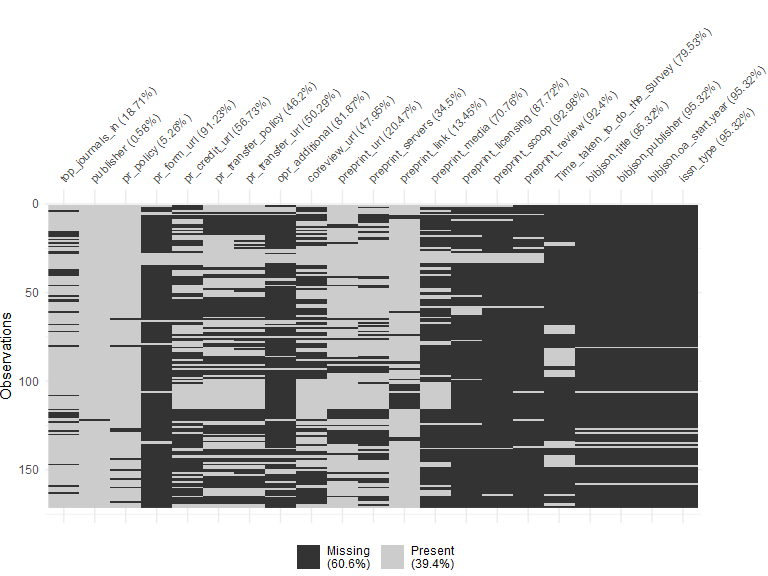

# Publisher versus subject area

The question is, whether it is reasonable to split results by publisher. I think it does not make much sense:

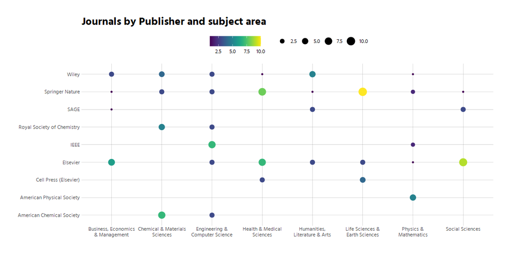

# Peer Review

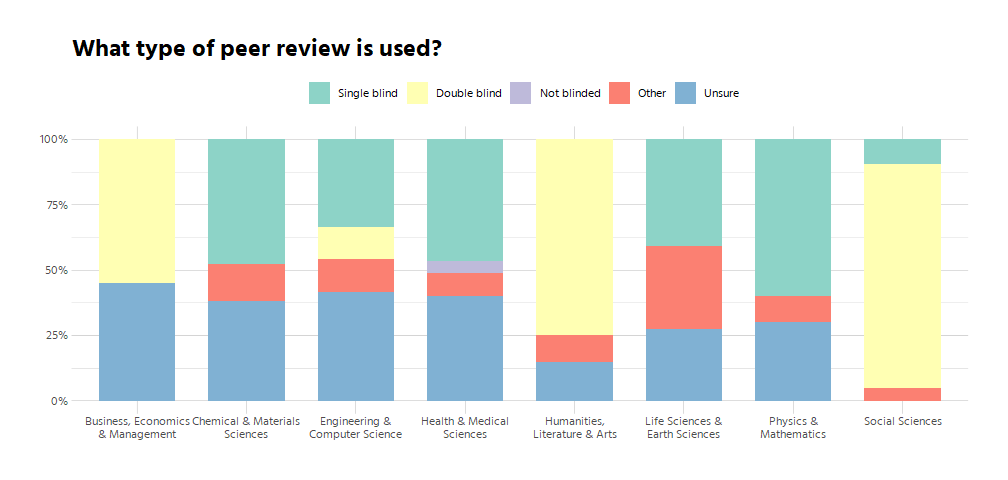

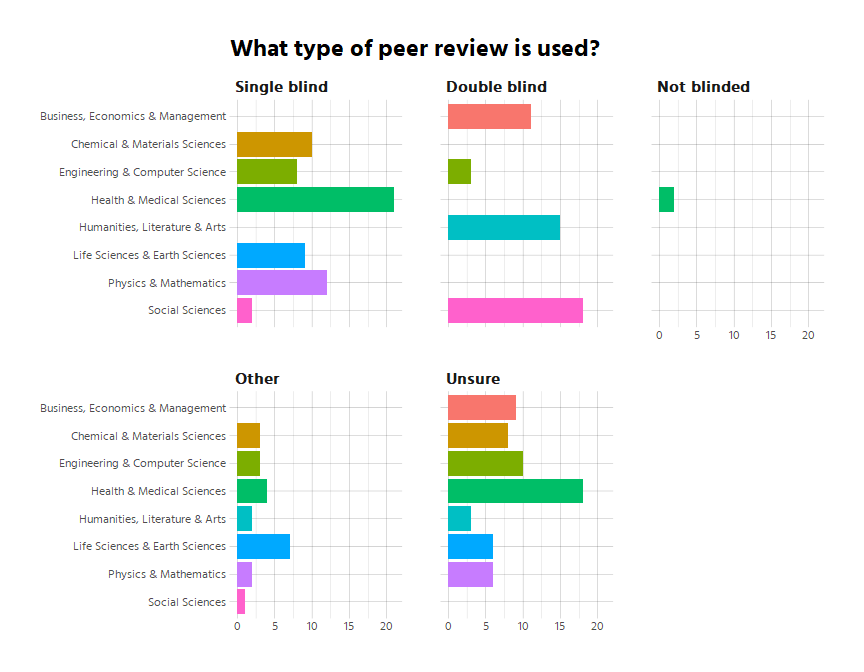

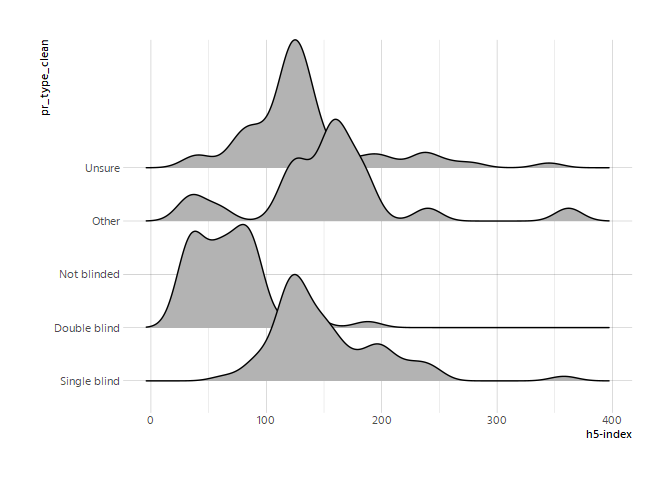

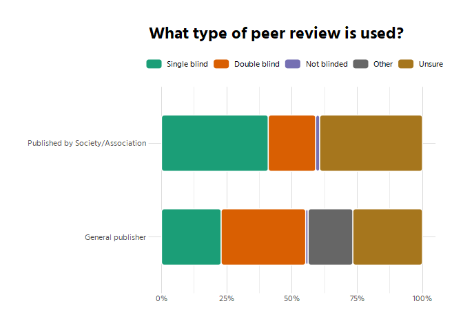

I don’t think this distinction is very interesting, since it masks disciplinary differences, which are more fundamental.

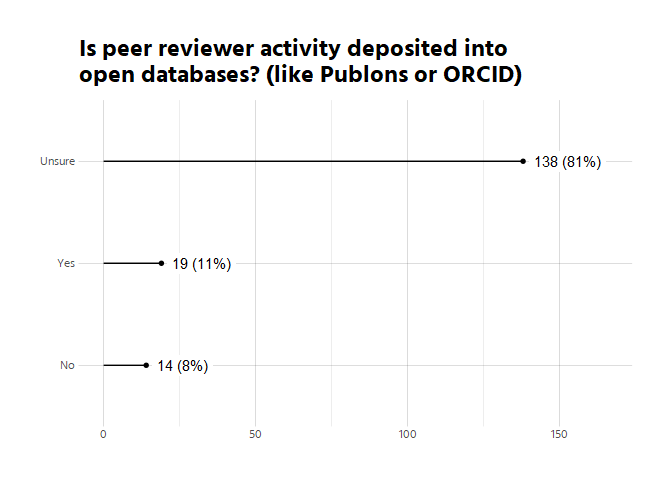

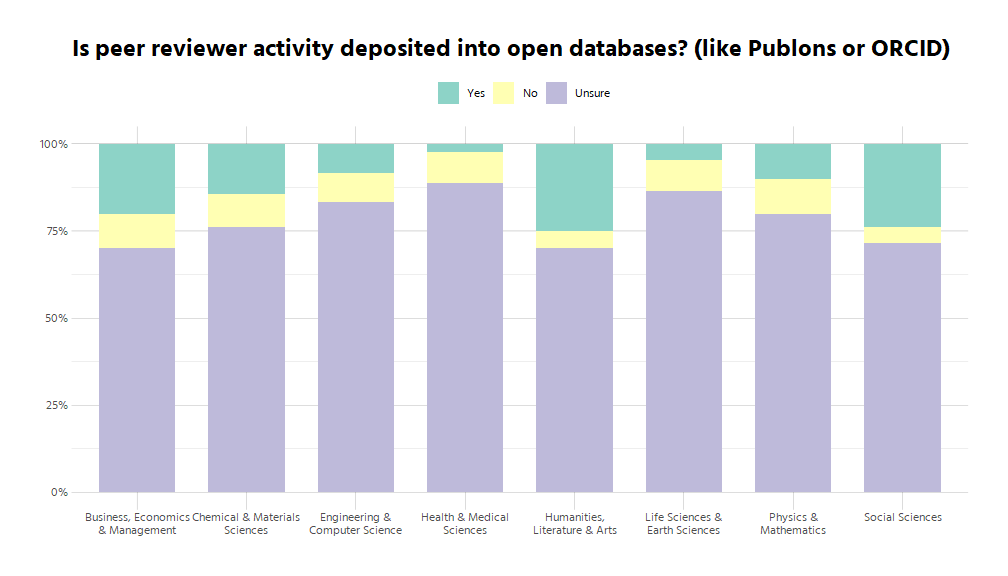

## Peer review transfer policy

Only 86 out of 171 do have a policy for manuscript transfer after rejection. Due to policies being similar across journals of certain publishers, there are 48 distinct policies in our dataset.

The following table displays stemmed parts of the distinct policies, sorted by propensity.

| word | n |
| --- | --- |
| journal | 160 |
| review | 140 |
| transfer | 116 |
| manuscript | 87 |
| editor | 52 |
| author | 51 |
| paper | 39 |
| submiss | 37 |
| articl | 36 |
| peer | 26 |

[output cut: 291 more lines]

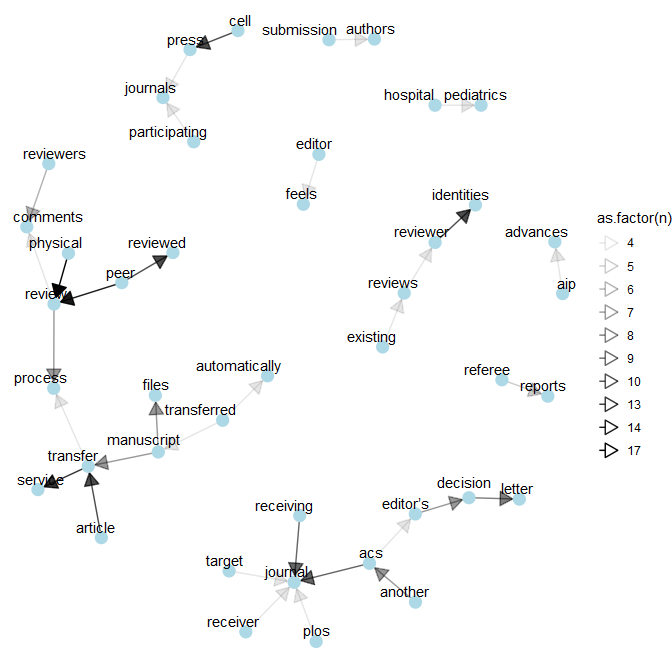

# Open Peer Review

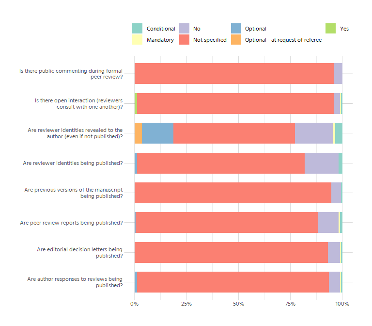

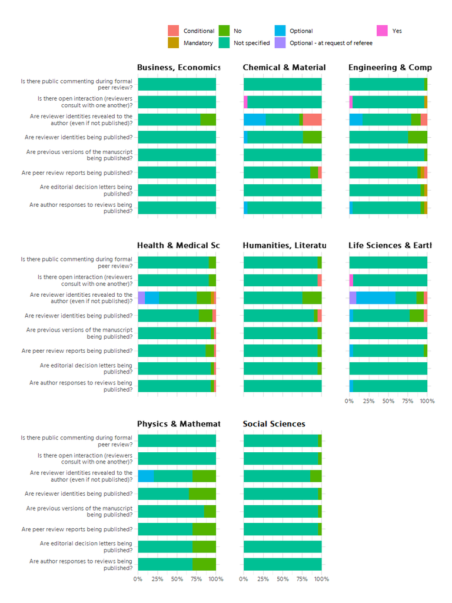

# Co-Review

Let’s look at the co-review policy.

Only 87 out of 171 do have a coreview-policy. Due to policies being similar across journals of certain publishers, there are 45 distinct policies in our dataset.

The following table displays stemmed parts of the distinct policies, sorted by propensity.

| word | n |
| --- | --- |
| review | 135 |
| manuscript | 53 |
| editor | 44 |
| confidenti | 34 |
| inform | 25 |
| colleagu | 21 |
| involv | 17 |
| journal | 17 |
| consult | 15 |
| discuss | 15 |

[output cut: 250 more lines]

The following graph shows the relationship between to most common bigrams (only bigrams that occur at least three times).

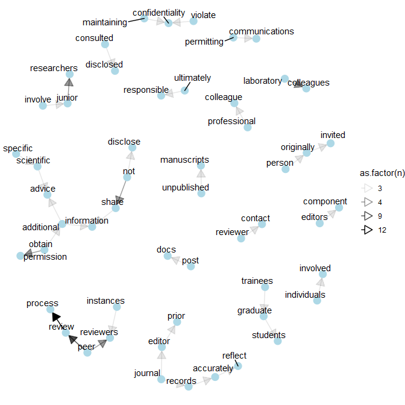

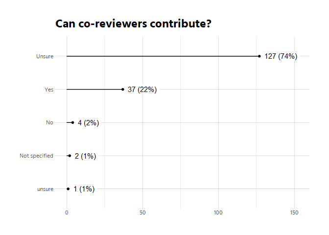

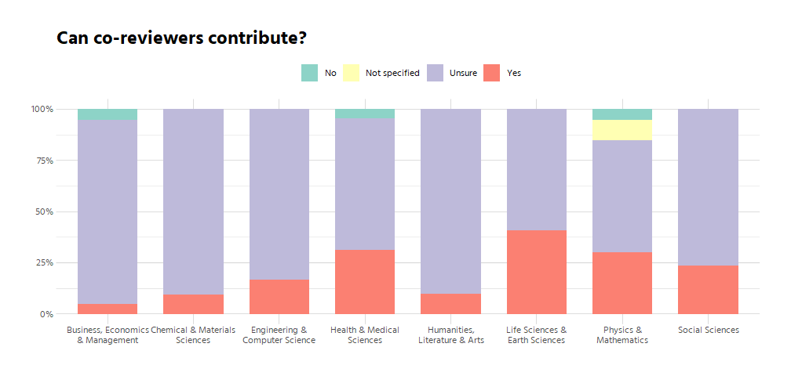

This doesn’t look interesting.

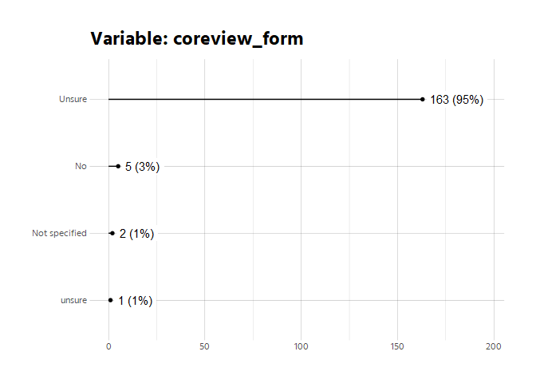

This doesn’t look interesting.

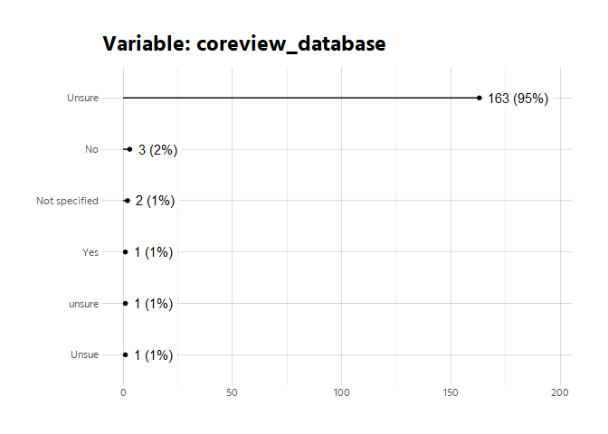

# Preprints

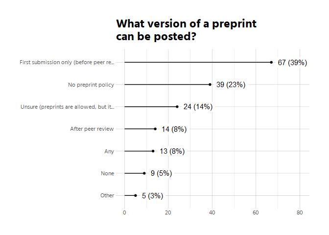

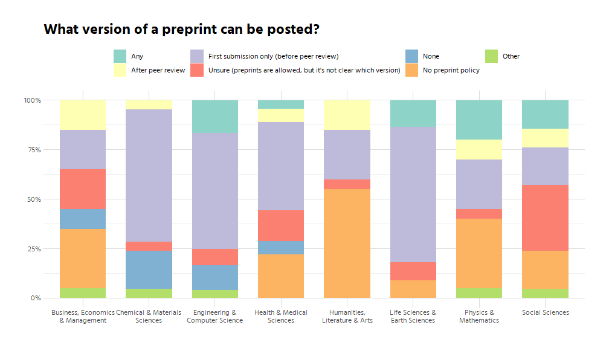

| word | n |
| --- | --- |
| preprint | 82 |
| publication | 59 |
| authors | 55 |
| manuscript | 40 |
| version | 33 |
| arxiv | 32 |
| server | 31 |
| published | 30 |
| servers | 30 |
| article | 27 |

[output cut: 550 more lines]

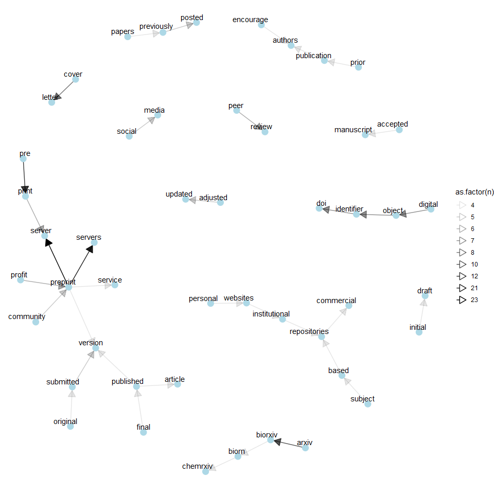

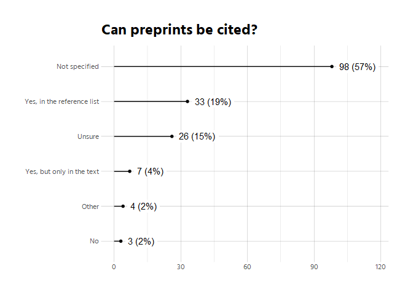

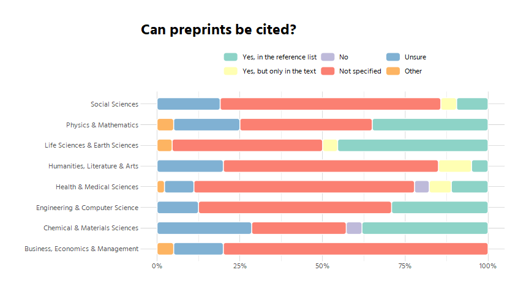

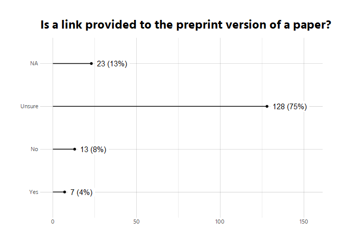

# Cross tabulations

Results so far have revealed that in many cases policies are unclear. But in which ways are policies related to each other? Do journals that allow co-review also allow preprints? Is there a gradient between journals that are pioneers in regard to open science, and others that lag behind? Or are there certain groups of journals, open in one area, reluctant in the second and maybe unclear in the third?

To answer these question, we employ Multiple Correspondence Analysis (MCA). The technique allows us to explore the different policies jointly (Greenacre & Blasius 2006: 27) and thus paint a landscape of open science practices among journals.

To facilitate interpration of the figures, variables had to be recoded. Categories with low counts were merged. Where feasible, we focused on whether certain policies were clear or not, thus omitting the subtle differences within the policies (for example whether journals allowed citations of preprints was simplified for whether the policy was clear (references allowed in text, reference list or not allowed) versus unclear (unsure about policy, no policy and other)).

It should be noted that the procedure is strictly exploratory. We are exploring, not testing any hypothesis.

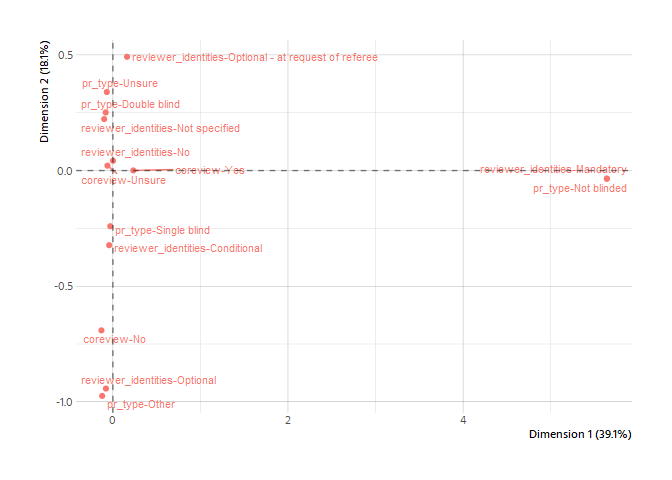

```
##
## Principal inertias (eigenvalues):
##
##  dim    value      %   cum%   scree plot
##  1      0.084830  48.1  48.1  ****************
##  2      0.018979  10.8  58.9  ****
##  3      0.017009   9.6  68.5  ***
##  4      0.006125   3.5  72.0  *
##  5      0.003927   2.2  74.2  *
##  6      0.001318   0.7  75.0
##  7      5.4e-050   0.0  75.0
##         -------- -----
##  Total: 0.176313
##
##
```

[output cut: 23 more lines]

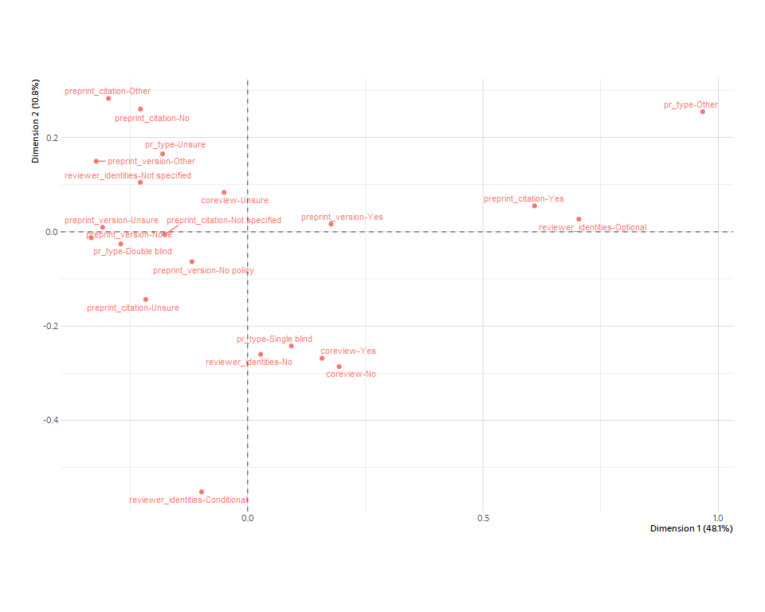

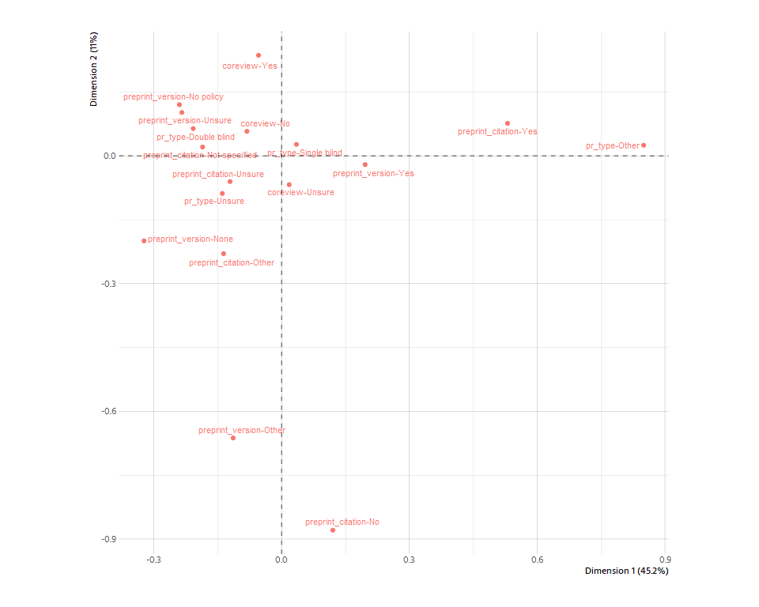

```
##
## Principal inertias (eigenvalues):
##
##  dim    value      %   cum%   scree plot
##  1      0.065420  47.6  47.6  *****************
##  2      0.014348  10.4  58.0  ****
##  3      0.008288   6.0  64.1  **
##  4      0.006491   4.7  68.8  **
##  5      0.003326   2.4  71.2  *
##  6      0.000656   0.5  71.7
##         -------- -----
##  Total: 0.137454
##
##
## Columns:
```

[output cut: 26 more lines]

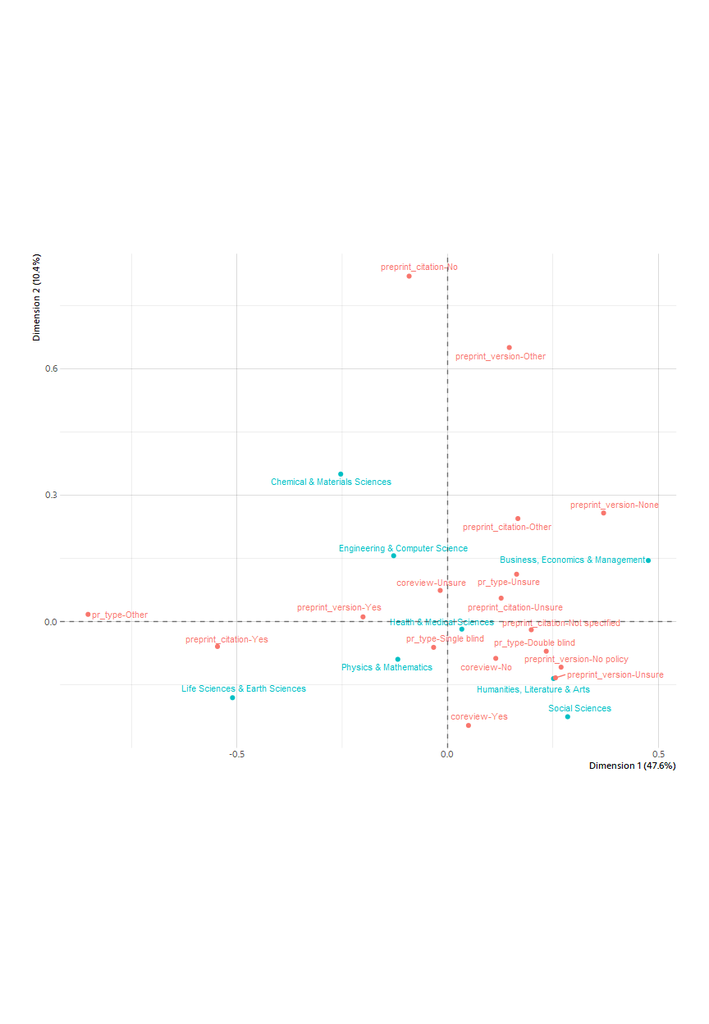

This looks intelligble, but lets try one more time with this crude variable

```
##
## Principal inertias (eigenvalues):
##
##  dim    value      %   cum%   scree plot
##  1      0.094812  50.8  50.8  *****************
##  2      0.020753  11.1  61.9  ****
##  3      0.014912   8.0  69.8  ***
##  4      0.006140   3.3  73.1  *
##  5      0.003838   2.1  75.2  *
##  6      0.001308   0.7  75.9
##  7      7e-05000   0.0  75.9
##         -------- -----
##  Total: 0.186803
##
##
```

[output cut: 31 more lines]

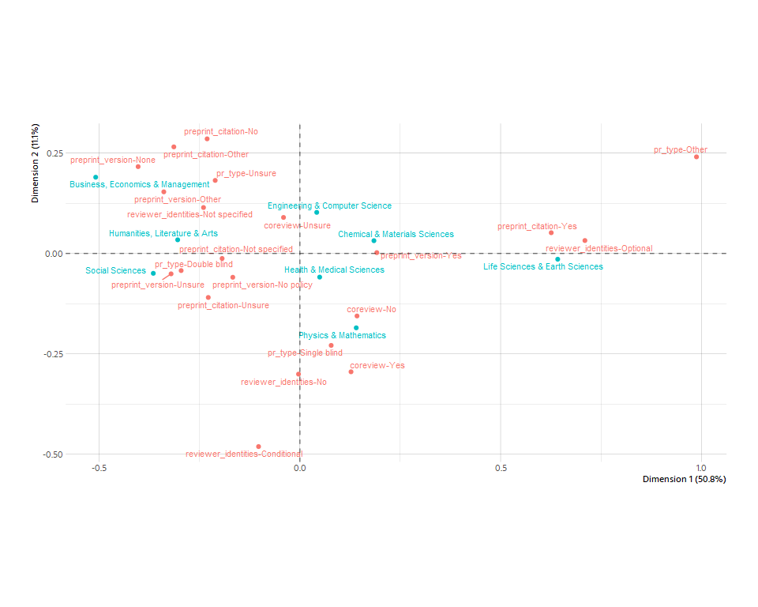

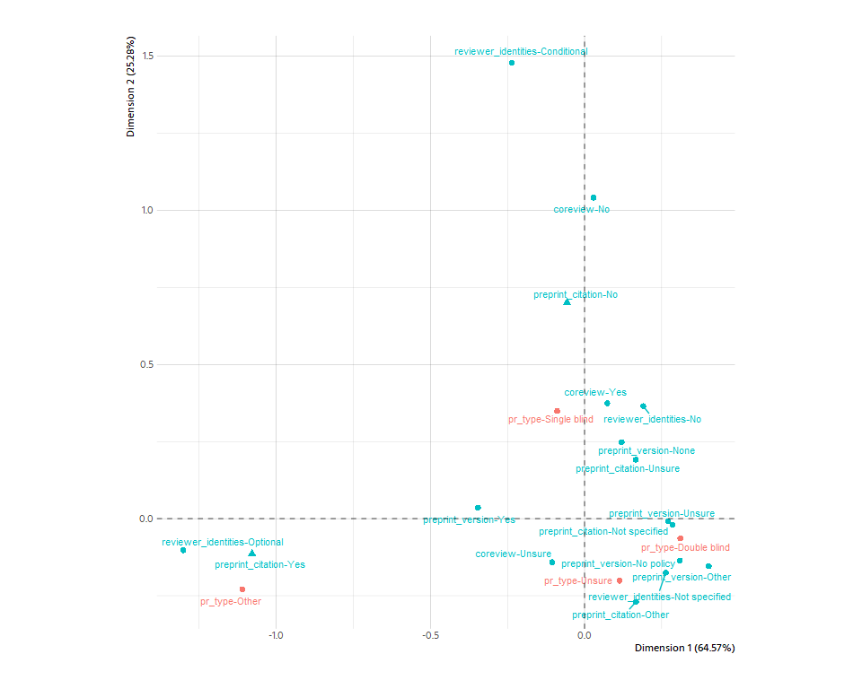

```
##
##  Pearson's Chi-squared test
##
## data:  .
## X-squared = 259.28, df = 105, p-value = 4.713e-15
```

```
## [1] 0.2201843
```

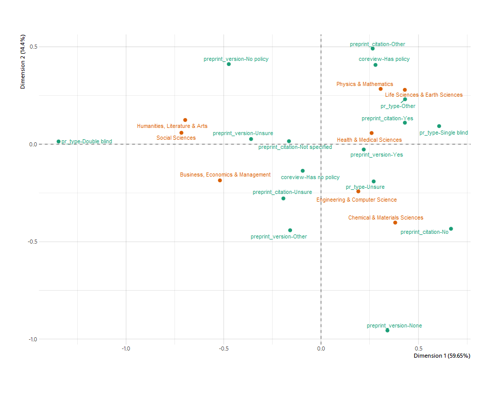

First axis is distinction between SSH and sciences. Second axis is more difficult in terms of what it means. It also has not that much inertia, thus being not very influential

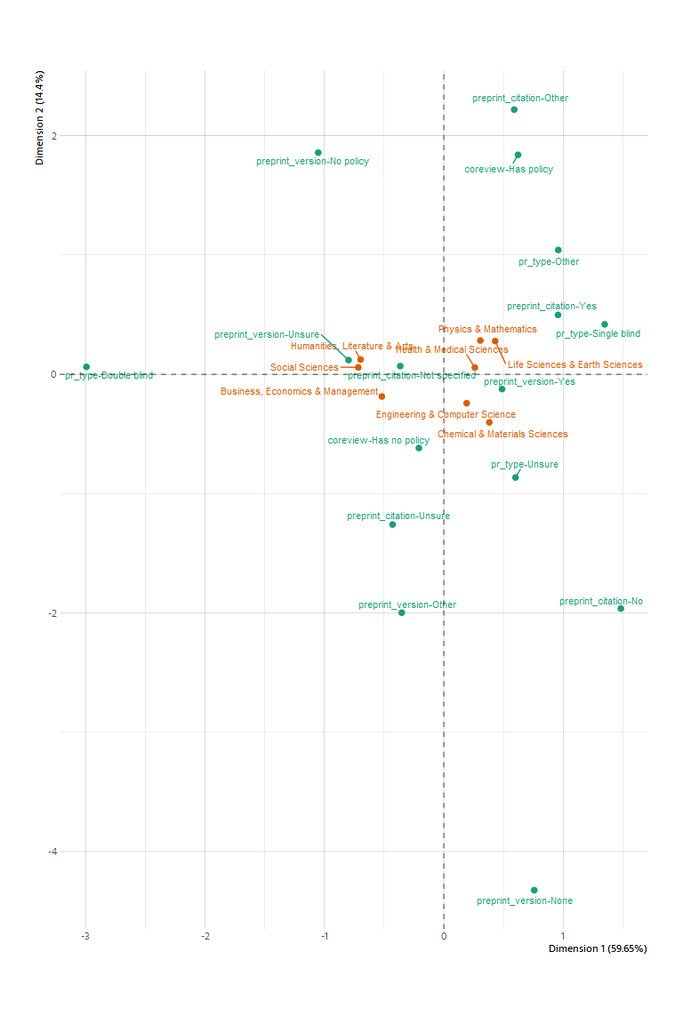

```
##
## Principal inertias (eigenvalues):
##
##  dim    value      %   cum%   scree plot
##  1      0.202431  59.6  59.6  ***************
##  2      0.048870  14.4  74.0  ****
##  3      0.035233  10.4  84.4  ***
##  4      0.024852   7.3  91.8  **
##  5      0.016925   5.0  96.7  *
##  6      0.008446   2.5  99.2  *
##  7      0.002610   0.8 100.0
##         -------- -----
##  Total: 0.339368 100.0
##
##
```

[output cut: 29 more lines]

```
##
##  Principal inertias (eigenvalues):
##            1        2       3        4        5        6        7
## Value      0.202431 0.04887 0.035233 0.024852 0.016925 0.008446 0.00261
## Percentage 59.65%   14.4%   10.38%   7.32%    4.99%    2.49%    0.77%
##
##
##  Rows:
##         coreview-Has no policy coreview-Has policy preprint_version-No policy preprint_version-None preprint_version-Other preprint_version-Unsure
## Mass                  0.187173            0.062827                   0.051047              0.015707               0.006545                0.032723
## ChiDist               0.176868            0.526919                   0.805284              1.025120               0.899974                0.676312
## Inertia               0.005855            0.017444                   0.033103              0.016506               0.005301                0.014967
## Dim. 1               -0.208662            0.621639                  -1.051879              0.757799              -0.352191               -0.797899
## Dim. 2               -0.617497            1.839628                   1.858271             -4.323368              -1.997743                0.119226
##         preprint_version-Yes preprint_citation-No preprint_citation-Not specified preprint_citation-Other preprint_citation-Unsure preprint_citation-Yes
## Mass                0.143979             0.003927                        0.143979                0.005236                 0.035340              0.061518
## ChiDist             0.267798             1.408809                        0.264054                1.006966                 0.582205              0.576274
## Inertia             0.010326             0.007793                        0.010039                0.005309                 0.011979              0.020430
## Dim. 1              0.487619             1.483073                       -0.365443                0.589690                -0.429116              0.956954
## Dim. 2             -0.123492            -1.963233                        0.069211                2.219163                -1.259100              0.497778
##         pr_type-Double blind pr_type-Other pr_type-Single blind pr_type-Unsure
## Mass                0.061518      0.028796             0.081152       0.078534
## ChiDist             1.364655      0.720790             0.654872       0.451213
## Inertia             0.114565      0.014961             0.034803       0.015989
## Dim. 1             -2.993924      0.959127             1.347637       0.601002
## Dim. 2              0.062737      1.042317             0.419260      -0.864563
##
##
##  Columns:
##         Business, Economics & Management Chemical & Materials Sciences Engineering & Computer Science Health & Medical Sciences
## Mass                            0.104712                      0.109948                       0.125654                  0.225131
## ChiDist                         0.632291                      0.609887                       0.361956                  0.381467
## Inertia                         0.041863                      0.040896                       0.016462                  0.032760
## Dim. 1                         -1.153188                      0.846897                       0.425946                  0.577454
## Dim. 2                         -0.840234                     -1.819903                      -1.095257                  0.258944
##         Humanities, Literature & Arts Life Sciences & Earth Sciences Physics & Mathematics Social Sciences
## Mass                         0.104712                       0.115183              0.104712        0.109948
## ChiDist                      0.783012                       0.612972              0.526766        0.802754
## Inertia                      0.064200                       0.043278              0.029056        0.070852
## Dim. 1                      -1.549271                       0.956480              0.680514       -1.592465
## Dim. 2                       0.561214                       1.260950              1.282670        0.264554
```

Axes are mainly determined by peer review policy. Maybe remove this variable to bring out mor subtle and potentialy more meaningful answers regarding the key topics (that SSH have double blind and Sciences have single blind seems to be well established)

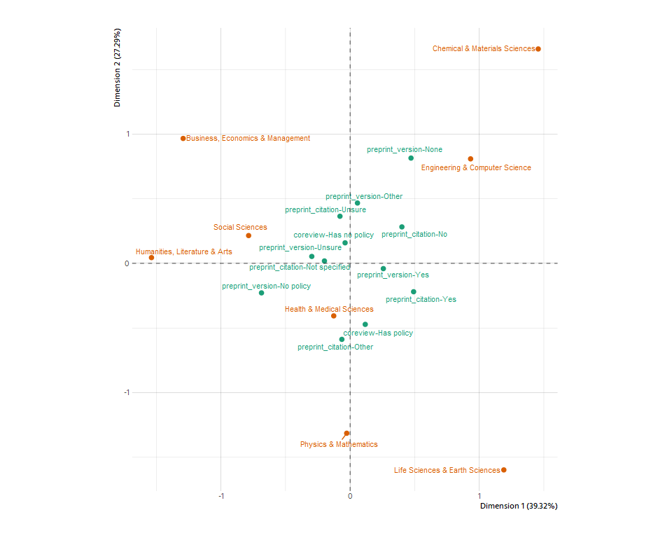